# Flights Data Exploration

## by Ibrahim Alraigi

## Preliminary Wrangling

> Have you ever been stuck in an airport because your flight was delayed or cancelled and wondered if you could have predicted it if you'd had more data? This is our chance to find out!

That was the challenge by RITA when they provided this dataset, it consists of flight arrival and departure details for all commercial flights within the USA for the year 2008. It is a huge "Airline on-time performance" dataset that contains 7,009,728 flights with 29 features.

```python
#temporaly display all 29 columns
with pd.option_context('display.max_columns', 29):
    display(df.head(10))
```

|  | Year | Month | DayofMonth | DayOfWeek | DepTime | CRSDepTime | ArrTime | CRSArrTime | UniqueCarrier | FlightNum | TailNum | ActualElapsedTime | CRSElapsedTime | AirTime | ArrDelay | DepDelay | Origin | Dest | Distance | TaxiIn | TaxiOut | Cancelled | CancellationCode | Diverted | CarrierDelay | WeatherDelay | NASDelay | SecurityDelay | LateAircraftDelay |
| --- | --- | --- | --- | --- | --- | --- | --- | --- | --- | --- | --- | --- | --- | --- | --- | --- | --- | --- | --- | --- | --- | --- | --- | --- | --- | --- | --- | --- | --- |
| 0 | 2008 | 1 | 3 | 4 | 2003.0 | 1955 | 2211.0 | 2225 | WN | 335 | N712SW | 128.0 | 150.0 | 116.0 | -14.0 | 8.0 | IAD | TPA | 810 | 4.0 | 8.0 | 0 | NaN | 0 | NaN | NaN | NaN | NaN | NaN |
| 1 | 2008 | 1 | 3 | 4 | 754.0 | 735 | 1002.0 | 1000 | WN | 3231 | N772SW | 128.0 | 145.0 | 113.0 | 2.0 | 19.0 | IAD | TPA | 810 | 5.0 | 10.0 | 0 | NaN | 0 | NaN | NaN | NaN | NaN | NaN |
| 2 | 2008 | 1 | 3 | 4 | 628.0 | 620 | 804.0 | 750 | WN | 448 | N428WN | 96.0 | 90.0 | 76.0 | 14.0 | 8.0 | IND | BWI | 515 | 3.0 | 17.0 | 0 | NaN | 0 | NaN | NaN | NaN | NaN | NaN |
| 3 | 2008 | 1 | 3 | 4 | 926.0 | 930 | 1054.0 | 1100 | WN | 1746 | N612SW | 88.0 | 90.0 | 78.0 | -6.0 | -4.0 | IND | BWI | 515 | 3.0 | 7.0 | 0 | NaN | 0 | NaN | NaN | NaN | NaN | NaN |
| 4 | 2008 | 1 | 3 | 4 | 1829.0 | 1755 | 1959.0 | 1925 | WN | 3920 | N464WN | 90.0 | 90.0 | 77.0 | 34.0 | 34.0 | IND | BWI | 515 | 3.0 | 10.0 | 0 | NaN | 0 | 2.0 | 0.0 | 0.0 | 0.0 | 32.0 |
| 5 | 2008 | 1 | 3 | 4 | 1940.0 | 1915 | 2121.0 | 2110 | WN | 378 | N726SW | 101.0 | 115.0 | 87.0 | 11.0 | 25.0 | IND | JAX | 688 | 4.0 | 10.0 | 0 | NaN | 0 | NaN | NaN | NaN | NaN | NaN |
| 6 | 2008 | 1 | 3 | 4 | 1937.0 | 1830 | 2037.0 | 1940 | WN | 509 | N763SW | 240.0 | 250.0 | 230.0 | 57.0 | 67.0 | IND | LAS | 1591 | 3.0 | 7.0 | 0 | NaN | 0 | 10.0 | 0.0 | 0.0 | 0.0 | 47.0 |
| 7 | 2008 | 1 | 3 | 4 | 1039.0 | 1040 | 1132.0 | 1150 | WN | 535 | N428WN | 233.0 | 250.0 | 219.0 | -18.0 | -1.0 | IND | LAS | 1591 | 7.0 | 7.0 | 0 | NaN | 0 | NaN | NaN | NaN | NaN | NaN |
| 8 | 2008 | 1 | 3 | 4 | 617.0 | 615 | 652.0 | 650 | WN | 11 | N689SW | 95.0 | 95.0 | 70.0 | 2.0 | 2.0 | IND | MCI | 451 | 6.0 | 19.0 | 0 | NaN | 0 | NaN | NaN | NaN | NaN | NaN |
| 9 | 2008 | 1 | 3 | 4 | 1620.0 | 1620 | 1639.0 | 1655 | WN | 810 | N648SW | 79.0 | 95.0 | 70.0 | -16.0 | 0.0 | IND | MCI | 451 | 3.0 | 6.0 | 0 | NaN | 0 | NaN | NaN | NaN | NaN | NaN |

### Issues:

- `DepDelay` has some missing values, we will fix that by discovering a pattern that is related to those missing data or if we couldn't find one, we will just drop them since they represent only a very small portion
- `DepTime, CRSDepTime, ArrTime, CRSArrTime` are of type float rather than timedelta object
- `CarrierDelay, WeatherDelay, NASDelay, SecurityDelay, LateAircraftDelay, CancellationCode` have both NaN's and 0's, covert all to 0's
- Add column `Delayed` if the flight is delayed based on `DepDelay` as 1 (Yes) or 0 (No)

```python
# our final clean dataset
# temporaly display all 30 columns
with pd.option_context('display.max_columns', 30):
    display(df_clean.head())
```

|  | Year | Month | DayofMonth | DayOfWeek | DepTime | CRSDepTime | ArrTime | CRSArrTime | UniqueCarrier | FlightNum | TailNum | ActualElapsedTime | CRSElapsedTime | AirTime | ArrDelay | DepDelay | Origin | Dest | Distance | TaxiIn | TaxiOut | Cancelled | CancellationCode | Diverted | CarrierDelay | WeatherDelay | NASDelay | SecurityDelay | LateAircraftDelay | … |
| --- | --- | --- | --- | --- | --- | --- | --- | --- | --- | --- | --- | --- | --- | --- | --- | --- | --- | --- | --- | --- | --- | --- | --- | --- | --- | --- | --- | --- | --- | --- |
| 0 | 2008 | 1 | 3 | 4 | 20:03:00 | 19:55:00 | 22:11:00 | 22:25:00 | WN | 335 | N712SW | 128.0 | 150.0 | 116.0 | -14.0 | 8.0 | IAD | TPA | 810 | 4.0 | 8.0 | 0 | 0 | 0 | 0.0 | 0.0 | 0.0 | 0.0 | 0.0 | … |
| 1 | 2008 | 1 | 3 | 4 | 07:54:00 | 07:35:00 | 10:02:00 | 10:00:00 | WN | 3231 | N772SW | 128.0 | 145.0 | 113.0 | 2.0 | 19.0 | IAD | TPA | 810 | 5.0 | 10.0 | 0 | 0 | 0 | 0.0 | 0.0 | 0.0 | 0.0 | 0.0 | … |
| 2 | 2008 | 1 | 3 | 4 | 06:28:00 | 06:20:00 | 08:04:00 | 07:50:00 | WN | 448 | N428WN | 96.0 | 90.0 | 76.0 | 14.0 | 8.0 | IND | BWI | 515 | 3.0 | 17.0 | 0 | 0 | 0 | 0.0 | 0.0 | 0.0 | 0.0 | 0.0 | … |
| 3 | 2008 | 1 | 3 | 4 | 09:26:00 | 09:30:00 | 10:54:00 | 11:00:00 | WN | 1746 | N612SW | 88.0 | 90.0 | 78.0 | -6.0 | -4.0 | IND | BWI | 515 | 3.0 | 7.0 | 0 | 0 | 0 | 0.0 | 0.0 | 0.0 | 0.0 | 0.0 | … |
| 4 | 2008 | 1 | 3 | 4 | 18:29:00 | 17:55:00 | 19:59:00 | 19:25:00 | WN | 3920 | N464WN | 90.0 | 90.0 | 77.0 | 34.0 | 34.0 | IND | BWI | 515 | 3.0 | 10.0 | 0 | 0 | 0 | 2.0 | 0.0 | 0.0 | 0.0 | 32.0 | … |

### What is the structure of your dataset?

We have a large "Airline on-time performance" dataset that contains 7,009,728 flights with 29 features. The dataset was in year 2008.

Some issues were found and resolved to make the dataset better for analyzing and visualizing, such as errornus data types, inconsistent null value and some missing usefull columns.

### What is/are the main feature(s) of interest in your dataset?

I'm most interested in figuring out the following:

- what features are best for predicting whether there will be a delay for the flight or not.
- what features are best for predicting whether the flight will be canceled or not.

### What features in the dataset do you think will help support your investigation into your feature(s) of interest?

The dataset was posted intentionally vague in order to allow different entries to focus on different aspects of the data, but generally speaking features such as Origin, Weather, Diverted flights and Carrier might have major effect in delaying or canceling a flight.

## Univariate Exploration

let's start by looking at the main variable of interest

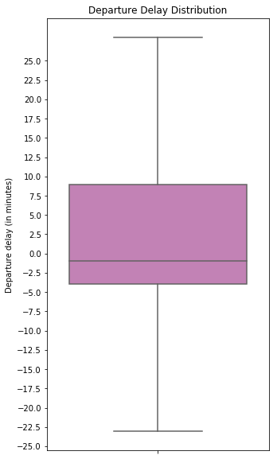

```python
# seems like we have outliers, hence, we won't show them for better visualization
plt.figure(figsize=[5, 10])
sb.boxplot(y="DepDelay", data=df_clean, color=color, showfliers=False)
plt.ylabel('Departure delay (in minutes)')
plt.yticks(np.arange(-25, 25+2.5, 2.5))
plt.title('Departure Delay Distribution')
plt.show();
```

Let's check different types of delayes, that are the ones in columns:CarrierDelay, WeatherDelay, NASDelay, SecurityDelay, LateAircraftDelay

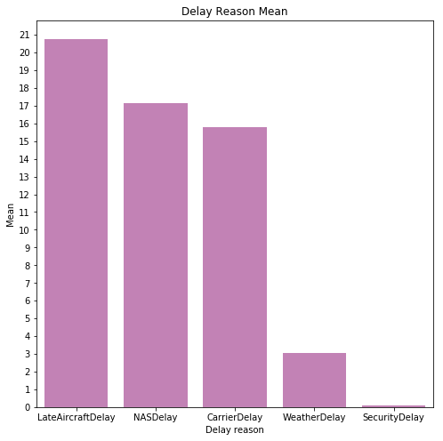

```python
col_list = ['CarrierDelay', 'WeatherDelay', 'NASDelay', 'SecurityDelay', 'LateAircraftDelay']
y = df[col_list].mean().sort_values(ascending=False)
x = y.index

plt.figure(figsize=[8, 8])
sb.barplot(y = y, x = x, color = color, )
plt.ylabel('Mean')
plt.xlabel('Delay reason')
plt.title('Delay Reason Mean')
plt.yticks(np.arange(0, df[col_list].mean().max()+1, 1))
plt.show()
```

Let's now check cancelled flights rate

We have around 2% cancelled flights

Let's also check different types of cancellation

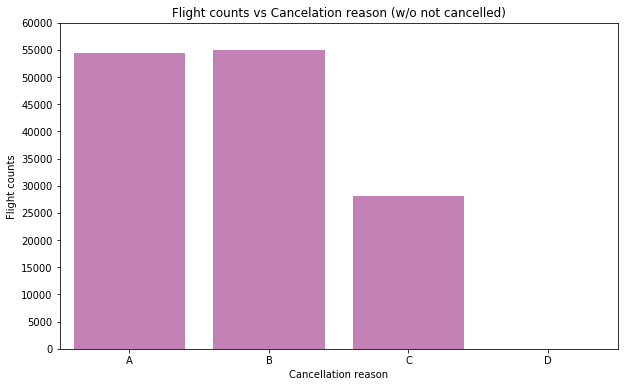

```python
ticks = ['A', 'B', 'C', 'D'];

plt.figure(figsize=[10, 6])
sb.countplot(data = df_clean, x = 'CancellationCode', color = color, order=ticks)
plt.yticks(np.arange(0, 60000+5000, 5000))
plt.ylabel('Flight counts')
plt.xlabel('Cancellation reason')
plt.title('Flight counts vs Cancelation reason (w/o not cancelled)')
plt.show();
```

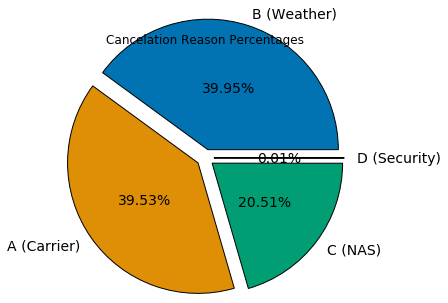

```python
y = np.array(list(df_clean[df_clean['CancellationCode'] != 'None']['CancellationCode'].value_counts())[1:5])
labels = ['B (Weather)', 'A (Carrier)', 'C (NAS)', 'D (Security)']
explode = (0.1, 0.1, 0.1, 0.1)
wedgeprops={"edgecolor":"k", 'antialiased': True}

plt.pie(y, labels=labels, autopct='%1.2f%%', pctdistance=0.5,
        labeldistance=1.1, radius=1.5, textprops={'fontsize': 14},
        explode=explode, colors=colors, wedgeprops=wedgeprops)
plt.title('Cancelation Reason Percentages')
plt.show()
```

### Of the features you investigated, were there any unusual distributions? Did you perform any operations on the data to tidy, adjust, or change the form of the data? If so, why did you do this?

- I added a new column `Delayed` if the flight is delayed or not based on `DepDelay`, if it's greater than 5 minutes it's considered to be felayed, as 1 (Yes) or 0 (No).
- Many outliers were found in column `DepDelay`, they were ignored in visualization so that we can draw better conclusions
- In both variables of intrest, there were NaN's instead of 0's, so that was changed to 0's for easier processing

## Bivariate Exploration

Let's start with the paiwise correlation between our variables of intrest (`Delayed` and `Cancelled`) and other variables.

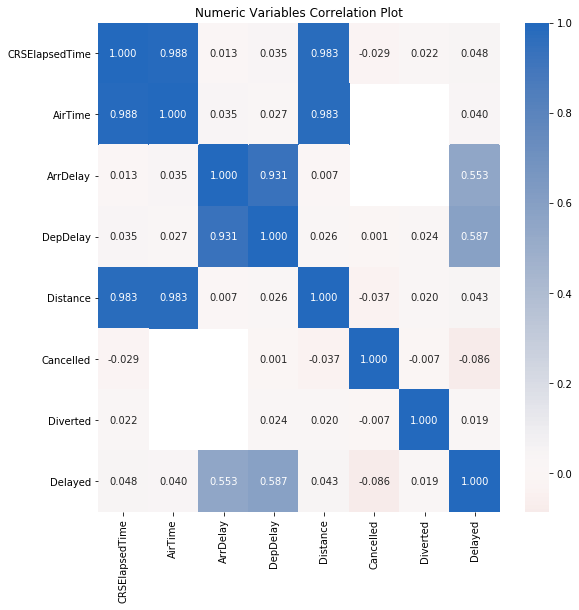

```python
# correlation plot
numeric_vars = ['CRSElapsedTime', 'AirTime', 'ArrDelay',
                'DepDelay', 'Origin', 'Dest', 'Distance',
                'Cancelled', 'Diverted', 'Delayed']
plt.figure(figsize = [9, 9])
sb.heatmap(df_clean[numeric_vars].corr(), annot = True, fmt = '.3f',
           cmap = 'vlag_r', center = 0)
plt.title('Numeric Variables Correlation Plot')
plt.show()
```

Let's check other nun-numeric (categorical) features that may have some effects on delaying or canelling flights such as Origin, Diverted flights and Carrier

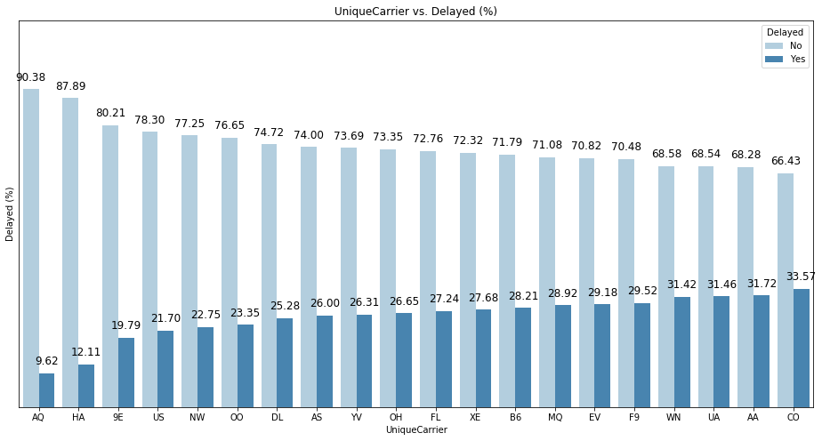

```python
bar_by_column('UniqueCarrier', 'Delayed')
```

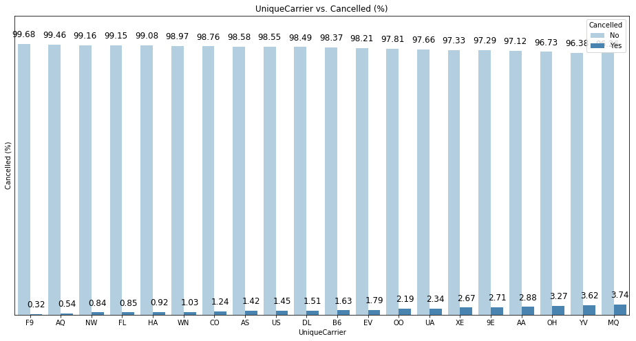

```python
bar_by_column('UniqueCarrier', 'Cancelled')
```

Let's move to another categorical variable, let's now check how Origin affects delaying and canceling flights

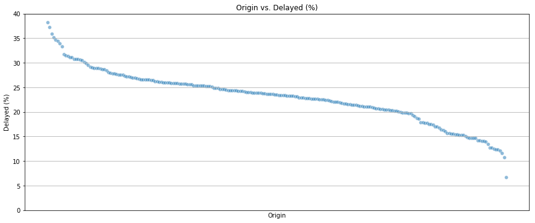

```python
data = df_clean[df_clean['Origin'].isin(origins)]
delayed_flights_by_origin = get_counts_percentages(data, 'Origin', 'Delayed')

scatter_by_column(delayed_flights_by_origin, 'Origin', 'Delayed')
```

Now, let's also check how origins affect cancelling flight rates

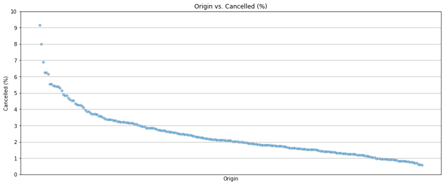

```python
# we will use the same data that excluded those orgins with few flights
cancelled_flights_by_origin = get_counts_percentages(data, 'Origin', 'Cancelled')

scatter_by_column(cancelled_flights_by_origin, 'Origin', 'Cancelled')
plt.yticks(np.arange(0,cancelled_flights_by_origin['Cancelled (%)'].max()+1,1));
```

Next, let's check if the day of the week affect the delaying and cancelling rates

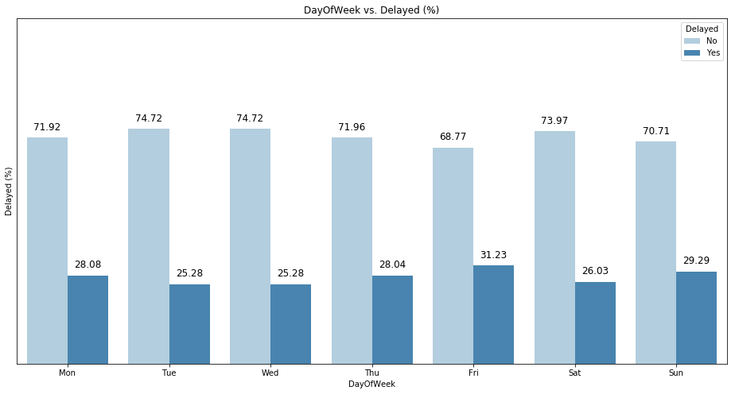

```python
bar_by_column('DayOfWeek', 'Delayed')
days = ['Mon', 'Tue', 'Wed', 'Thu', 'Fri', 'Sat', 'Sun']
plt.xticks(range(len(days)), days);
```

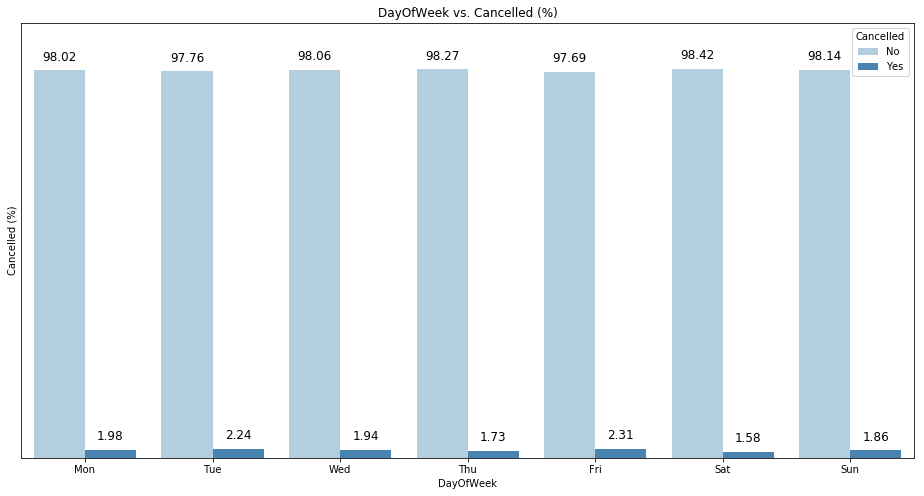

```python
bar_by_column('DayOfWeek', 'Cancelled')
days = ['Mon', 'Tue', 'Wed', 'Thu', 'Fri', 'Sat', 'Sun']
plt.xticks(range(len(days)), days);
```

Let's also check how scheduled departure time affects delaying or canceling flights

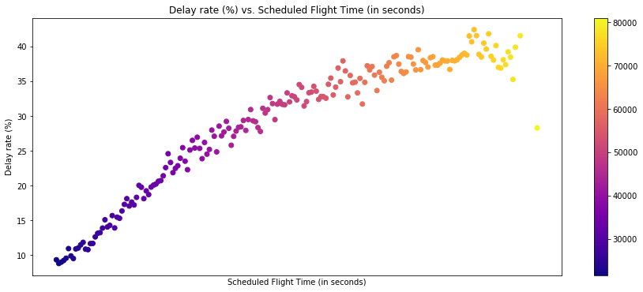

```python
plt.figure(figsize=[15,6])
plt.scatter(data=delayed_flights_by_dep_time, x='CRSDepTime', y='Delayed (%)', c='CRSDepTime', cmap='plasma')
plt.xticks([])
plt.xlabel('Scheduled Flight Time (in seconds)')
plt.ylabel('Delay rate (%)')
plt.title('Delay rate (%) vs. Scheduled Flight Time (in seconds)')
plt.colorbar();
```

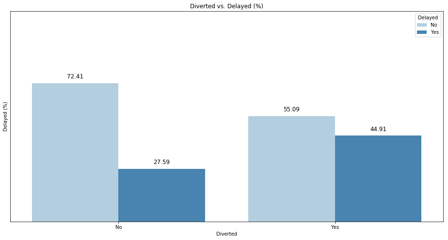

```python
bar_by_column('Diverted', 'Delayed')
ticks = ['No', 'Yes']
plt.xticks(range(len(ticks)), ticks);
```

### Talk about some of the relationships you observed in this part of the investigation. How did the feature(s) of interest vary with other features in the dataset?

Many categorical features have relationships with the features of interest (i.e. `Delayed` and `Cancelled`), such as `UniqueCarrier, Origin, Dest, DayOfWeek, CRSDepTime and Diverted`.

### Did you observe any interesting relationships between the other features (not the main feature(s) of interest)?

Expected realtionships were found, such as the departure delay with arraival delay, because departure delay will cause delay for next flight and so on. Also, a big correlation between the three variables ElapsedTime, AirTime and Distance, since they all depend on each others with small defrences.

## Multivariate Exploration

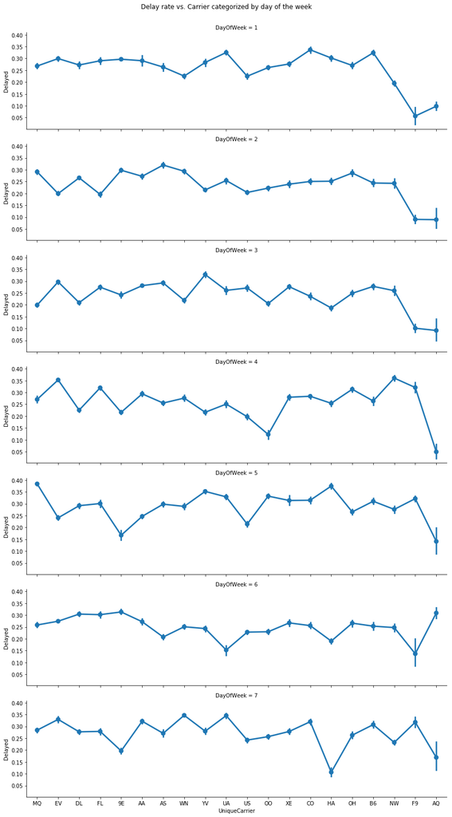

```python
# Delayed, DayOfWeek, UniqueCarrier
g = sb.FacetGrid(data=samp, col='DayOfWeek', col_wrap=1, aspect=4)
g.map(sb.pointplot, 'UniqueCarrier', 'Delayed')
g.fig.suptitle('Delay rate vs. Carrier categorized by day of the week', y=1.02);
```

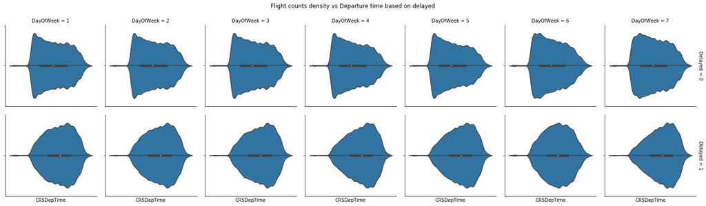

```python
# Delayed, DayOfWeek, DepTime
samp.CRSDepTime = samp.CRSDepTime.astype('timedelta64[s]').sort_values()
g = sb.FacetGrid(data=samp, col='DayOfWeek', row='Delayed', margin_titles=True)
g.map(sb.violinplot, 'CRSDepTime');
g.set(xticks=[])
g.fig.suptitle('Flight counts density vs Departure time based on delayed', y=1.05);
```

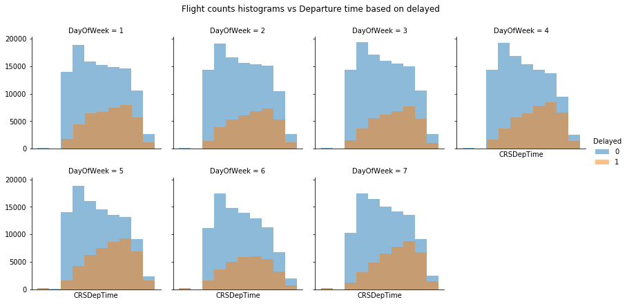

```python
g = sb.FacetGrid(data=samp, col='DayOfWeek', hue='Delayed', height=3, col_wrap=4)
g = (g.map(plt.hist, 'CRSDepTime', alpha=.5).add_legend())
g.set(xticks=[]);
g.fig.suptitle('Flight counts histograms vs Departure time based on delayed', y=1.05);
```

So clearly from the violinplot and the histograms, day of the week doesn't affect the delay rate based on the departure time, on almost all days, high delay rates are skewed to the right, while low delay rates are skewed to the left, meaning, late departure times have high delay rates while early departure times have low delay rates relatively.

### Talk about some of the relationships you observed in this part of the investigation. Were there features that strengthened each other in terms of looking at your feature(s) of interest?

Other than that the way that departure times were affecting flights delay rate didn't change when categorized them by the day of the week. Which supports what we observed before about the strong relationship between departure times and flights delay rates.

### Were there any interesting or surprising interactions between features?

Yes, some carriers seem to act differently based on the day of the week while some others are consistent. This might be due to the fact that some carriers are following consistent professional working standards while others tend to be less professional by the end of the week.